# Frequentist and Bayesian multiple imputation of phylogenetic traits under Rubin’s rules: a simulation study

# 2 Methods

## 2.1 Aims

1. **Primary.** Estimate the coverage and bias of Rubin-pooled estimates for BACE as shipped and for proper and fixed-parameter frequentist MI on continuous traits.
2. **Secondary.** Compare the accuracy and calibration of imputed classes, and the Rubin-pooled estimate of an association involving a discrete trait, between BACE and castor on the same datasets.

The chained variant of BACE and the extra-residual control were added after a pre-run showed BACE as shipped under-covering, and they were evaluated on the same seeds; they were not validated on fresh seeds (Limitations).

## 2.2 Data-generating mechanism

Each dataset is built from n, λ, ρ and an integer seed. For a given n and seed, the tree and the underlying random numbers are the same in all six (λ, ρ) scenarios, so comparisons between scenarios use common random numbers.

Under this mechanism c2 = ρ c1 + *e* with *e* ~ N(0, (1 − ρ²)*V*<sub>λ</sub>). A phylogenetic generalised least squares (PGLS) regression of c2 on c1 with Pagel’s λ is correctly specified, and both the population slope and the phylogenetic correlation of c1 and c2 equal ρ.

## 2.3 Estimands and targets

1. **Each missing value.** The true value of each masked c1 and c2 (prp on the logit scale, not reported here), and the true class of each masked bin, ord and cat3.
2. **PGLS slope of c2 on c1**, Pagel’s λ estimated by REML on [0, 1]. Target: ρ.
3. **Phylogenetic correlation of c1 and c2**, both traits whitened with the λ of the slope fit, on Fisher’s z with variance 1/(n − 3). Target: ρ.
4. **PGLS slope of c1 on bin** (bin = 1 for “yes”). Regressing a continuous trait on a 0/1 trait does not give ρ: the expected slope depends on the tree. The **per-dataset target** is ρ times the GLS slope, at the true λ, of *L*<sub>5</sub> on bin: the expected complete-data estimate given the tree and the binary trait’s liability, when λ is known. Because it conditions on *L*<sub>5</sub>, which carries more information than bin, the complete-data interval is expected to cover it at the nominal rate at ρ = 0 and slightly conservatively at ρ = 0.5 (observed 0.905 to 0.973 and 0.955 to 0.985), and methods are compared with the complete-data row rather than with 0.95. A **population target**, the mean complete-data estimate over 5,000 fresh datasets per scenario (Monte Carlo SE at most 0.007), agrees closely except at λ = 1 and ρ = 0.5, where the tree-specific slope varies between datasets by more than its standard error and even complete data cover the population target only 30% to 56% of the time. Coverage is therefore read against the per-dataset target; population-target coverage is in `data/discrete/agg_disc_down.csv`.

## 2.4 Methods compared

Every method produced M = 20 completed datasets for every dataset.

- **Frequentist, proper (continuous: Rphylopars).** One joint fit of c1, c2, logit(prp) and d1 with `Rphylopars::phylopars` (Pagel’s λ shared by the four traits, correlated phylogenetic covariance, REML). For each imputation: simulate a complete dataset from the fitted multivariate normal, mask it like the real data, refit, and draw the missing entries jointly from their conditional normal distribution given the observed entries under the refitted parameters. This parametric bootstrap stands in for the posterior of the parameters, so the scheme is approximately proper. A refit is rejected and redrawn (at most five times) if it fails, if λ leaves [0, 1] or the covariance is not positive definite, if its implied tip variance lies outside 1/50 to 50 times the original fit’s, or if its conditional distribution is degenerate; the original fit must itself imply a tip variance within 10<sup>4</sup> times the observed variance. Rejections were rare (the failures table). The count and discrete traits are not in this model.
- **Frequentist, fixed parameters (continuous: Rphylopars).** The same fit used once: 20 conditional draws with the parameters held at their estimates. This is improper and serves as a contrast.
- **BACE as shipped.** BACE 0.1.0 used as installed: one formula per trait on all other traits with a phylogenetic random effect, 5 runs of 50,000 iterations (burn-in 10,000, thinning 25), one-vs-rest models for cat3, and n<sub>final</sub> = 20 (launch: `script/rubin_campaign_nibi.sh`, `RUNS=5 NITT=50000`). BACE first cycles through the traits until the imputations settle, filling missing entries with posterior means. It then makes its 20 final imputations; each draws one posterior iteration plus a residual for every trait, but every one starts from the same settled dataset, so when a trait is imputed, the other traits’ missing entries are held at the same fills in all 20. Before fitting, unused factor levels are dropped and a discrete trait with fewer than two observed classes is left out; otherwise BACE stops at λ = 1. At λ = 1 this cleaning was needed in about half of the fits (53%, 51%, 47% at n = 100, 300, 1000).
- **Chained BACE.** BACE’s own final step (`bace_final_imp`, n<sub>final</sub> = 1) run 20 times, each starting from the previous imputation instead of the shared dataset; same fit and settings, so it is paired with BACE as shipped. Successive chained imputations are consecutive sweeps of one Markov chain, not independent draws, and the first starts from the shared dataset.
- **BACE + extra residual (control).** BACE as shipped plus a second, independent residual draw on the Gaussian traits. It adds noise without removing the shared start, to show that extra noise alone is not the cure.
- **Frequentist, discrete (castor).** For each discrete trait separately, `castor::hsp_mk_model` fits an Mk model, the standard model for a discrete trait that jumps between states along branches at estimated rates. We used flexible rates (all rates different for bin and cat3; between adjacent levels only, each rate different, for ord), the observed class frequencies as root prior, and three optimiser starts. Missing species are filled by drawing their states jointly from the tree (forward filtering, backward sampling, with transition probabilities from the matrix exponential). The fixed-parameter version draws 20 times at the fitted rates. The proper version, for each imputation, simulates the trait on the tree at the fitted rates, keeps the observed species, refits, and draws once at the refitted rates; a refit under which the observed data are impossible is rejected and redrawn, bootstrap samples are redrawn until at least two classes are observed, and the root prior is not bootstrapped, all of which slightly understate parameter uncertainty. castor draws fill the frequentist datasets after their continuous draws, under separate seeds. A version with equal transition rates, as in our pilot, is reported for comparison. A discrete trait with one observed class is imputed as that class by every method.
- **Complete data.** The same analyses on the data before masking: the reference each method should reach.

No off-the-shelf phylogenetic frequentist method imputes discrete traits jointly with continuous ones, so the discrete comparison is between BACE and the trait-by-trait tool available to a user. The frequentist datasets therefore impute bin without c1 (castor) and c1 without bin (Rphylopars).

## 2.5 Pooling (Rubin’s rules)

For a downstream estimate with per-imputation estimates *Q̂*<sub>m</sub> and variances *U*<sub>m</sub>, the pooled estimate is *Q̄* = mean(*Q̂*<sub>m</sub>), with within-imputation variance *W* = mean(*U*<sub>m</sub>), between-imputation variance *B* = var(*Q̂*<sub>m</sub>) and total variance *T* = *W* + (1 + 1/M)*B*. Slope intervals use Barnard and Rubin’s (1999) degrees of freedom with complete-data degrees of freedom n − 2. The correlation is pooled on Fisher’s z with complete-data degrees of freedom treated as infinite (Rubin’s 1987 degrees of freedom) and back-transformed. The fraction of missing information (roughly, the share of the uncertainty due to the missing data) is reported. For a single missing continuous value *W* = 0, so its interval is the mean of the 20 draws ± *t*<sub>19</sub> √((1 + 1/M)*B*); if the truth and the draws are exchangeable normal variables this is an exact 95% prediction interval, so per-value coverage tests whether each value’s predictive distribution is calibrated, not whether the imputations are proper. A percentile interval of 20 draws (R’s default quantile type 7) covers only 0.872. PGLS slopes are fitted by an exact eigenbasis REML estimator, equal to `nlme::gls` with `corPagel` to within 10<sup>−4</sup>.

## 2.6 Performance measures

- **Continuous, per value.** Coverage of the Rubin interval; mean width and z-RMSE (RMSE of the pooled mean), both in units of the trait’s SD over observed entries; interval score, width + (2/α)(lower − *y*)1(*y* < lower)
  - (2/α)(*y* − upper)1(*y* > upper) with α = 0.05 (Gneiting & Raftery 2007). Averaged within a dataset over c1 and c2, then over datasets.
- **Discrete, per value**, from the 20 draws: accuracy of the most frequent imputed class (ties counted fractionally); the multi-class Brier score Σ<sub>k</sub>(*p̂*<sub>k</sub> − 1{*y* = *k*})² of the draw frequencies (Brier 1950), which carries the same finite-M term of about (1 − Σ<sub>k</sub> *p*<sub>k</sub>²)/20 for every method; coverage and size of the smallest set of classes holding 95% of the draws (ties at its edge counted fractionally), which for a calibrated imputer with 20 draws is at least 0.95 (0.96 to 1.00 for a binary trait), so it is compared between methods rather than against 0.95; and the accuracy of always guessing the most frequent observed class.
- **Downstream.** Coverage of the target, bias, RMSE, mean interval width, fraction of missing information, and the paired difference between each method’s pooled estimate and the complete-data estimate.
- **Monte Carlo error.** Aggregates are means over datasets. For per-value scores the SE is SD/√(datasets) of the dataset means (entries within a dataset share one fit). For downstream coverage (one interval per dataset) the SE is √(*p*(1 − *p*)/datasets), with *p* floored at 0.95 so that a coverage of 1.00 keeps an SE. Methods are compared on the same datasets by paired per-dataset differences.
- **Failures.** A fit that stops is recorded and not scored; failures are reported by scenario. A trait with one class in the complete data has nothing to predict and is left out of the discrete scores for every method.

## 2.7 Computing and reproducibility

Every fit ran on one core (`OPENBLAS_NUM_THREADS = 1`) on the Digital Research Alliance of Canada clusters fir, nibi and rorqual (Slurm job arrays) and on a University of Alberta server (at most 150 cores). Single-core time was about 6,110 hours for BACE and 114 for the frequentist methods in the continuous part, and 2,691 and 36 in the discrete part (supplementary table). Peak memory of one BACE fit was 2.4 GB at n = 100, 6 GB at n = 300 and 19 GB at n = 1000. Software: R 4.5.0 on the clusters and 4.5.3 on the server, BACE 0.1.0 (labelled 0.0.0.9000 on the server, with its fitting functions checked byte-identical), MCMCglmm 2.36, Rphylopars 0.3.10, castor 1.8.7, ape 5.8.1 (versions from the stored session information). Every result file stores its session information, the true data and the mask; the discrete runs also store all 20 imputations of every method, so every score can be recomputed without refitting.

The discrete part re-ran BACE. Re-runs on the cluster that produced the stored continuous fit reproduced 417 of 423 fits exactly; re-runs on another cluster differed (median absolute difference in a pooled estimate 0.004 to 0.016, maximum 0.62) and are independent replicates. The frequentist discrete datasets were also re-run; their continuous draws matched the continuous results of record exactly in 2,236 of 2,400 datasets and differed in the rest through machine-level numerical differences.

# 3 Results

## 3.1 Continuous traits

### 3.1.1 Single missing values

BACE as shipped under-covered single missing values at λ = 0.3 and 0.7 at every n (Table 1, Figure 1). Chaining the final imputations brought coverage to nominal; the extra-residual control was nominal at n = 100 but over-covered at n ≥ 300. Both frequentist methods were close to nominal throughout, including the fixed-parameter one, which confirms that per-value coverage checks calibration rather than properness. At λ = 1 all methods were near nominal and chained BACE slightly conservative.

Table 1: Coverage of the Rubin interval for single missing values of c1 and c2 (Monte Carlo SE), by n, λ and ρ. Nominal 0.95.

| n | λ | ρ | frequentist, proper | frequentist, fixed parameters | BACE as shipped | chained BACE | BACE + extra residual (control) |
| --- | --- | --- | --- | --- | --- | --- | --- |
| 100 | 0.3 | 0.0 | 0.938 (0.002) | 0.934 (0.002) | 0.876 (0.004) | 0.946 (0.002) | 0.946 (0.003) |
| 100 | 0.3 | 0.5 | 0.939 (0.002) | 0.936 (0.002) | 0.884 (0.004) | 0.947 (0.002) | 0.948 (0.003) |
| 100 | 0.7 | 0.0 | 0.936 (0.002) | 0.932 (0.002) | 0.889 (0.004) | 0.947 (0.002) | 0.945 (0.003) |
| 100 | 0.7 | 0.5 | 0.938 (0.002) | 0.936 (0.002) | 0.886 (0.004) | 0.949 (0.002) | 0.944 (0.003) |
| 100 | 1.0 | 0.0 | 0.951 (0.002) | 0.950 (0.002) | 0.946 (0.003) | 0.969 (0.002) | 0.953 (0.002) |
| 100 | 1.0 | 0.5 | 0.947 (0.002) | 0.946 (0.002) | 0.936 (0.003) | 0.969 (0.002) | 0.945 (0.003) |
| 300 | 0.3 | 0.0 | 0.947 (0.001) | 0.945 (0.001) | 0.885 (0.002) | 0.947 (0.001) | 0.957 (0.001) |
| 300 | 0.3 | 0.5 | 0.944 (0.001) | 0.945 (0.001) | 0.913 (0.002) | 0.946 (0.001) | 0.975 (0.001) |
| 300 | 0.7 | 0.0 | 0.946 (0.001) | 0.946 (0.001) | 0.897 (0.002) | 0.947 (0.001) | 0.962 (0.001) |
| 300 | 0.7 | 0.5 | 0.944 (0.001) | 0.946 (0.001) | 0.916 (0.002) | 0.945 (0.001) | 0.972 (0.001) |
| 300 | 1.0 | 0.0 | 0.956 (0.001) | 0.954 (0.001) | 0.953 (0.001) | 0.961 (0.001) | 0.958 (0.001) |
| 300 | 1.0 | 0.5 | 0.955 (0.001) | 0.956 (0.001) | 0.943 (0.002) | 0.959 (0.001) | 0.949 (0.002) |
| 1000 | 0.3 | 0.0 | 0.949 (0.001) | 0.950 (0.001) | 0.894 (0.002) | 0.949 (0.001) | 0.965 (0.001) |
| 1000 | 0.3 | 0.5 | 0.949 (0.001) | 0.950 (0.001) | 0.932 (0.001) | 0.950 (0.001) | 0.983 (0.001) |
| 1000 | 0.7 | 0.0 | 0.950 (0.001) | 0.950 (0.001) | 0.899 (0.002) | 0.949 (0.001) | 0.967 (0.001) |
| 1000 | 0.7 | 0.5 | 0.950 (0.001) | 0.950 (0.001) | 0.931 (0.001) | 0.948 (0.001) | 0.983 (0.000) |
| 1000 | 1.0 | 0.0 | 0.958 (0.001) | 0.958 (0.001) | 0.955 (0.001) | 0.960 (0.001) | 0.960 (0.001) |
| 1000 | 1.0 | 0.5 | 0.959 (0.001) | 0.959 (0.001) | 0.945 (0.001) | 0.956 (0.001) | 0.951 (0.001) |

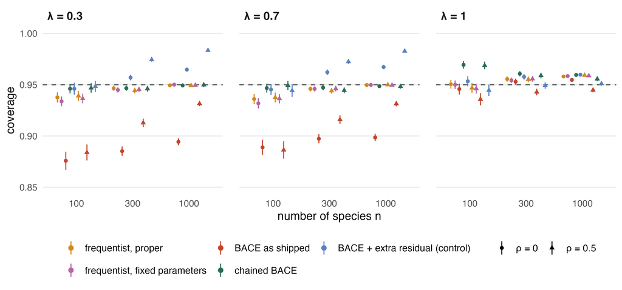

Figure 1: Coverage of single missing values by n and λ (circles ρ = 0, triangles ρ = 0.5); whiskers ±2 Monte Carlo SE. Dashed line: nominal 0.95.

The proper frequentist method was the more accurate at n = 100 and at λ = 1. At n ≥ 300 and λ ≤ 0.7 chained BACE was more accurate (Table 2), probably because it also conditions on the count and discrete traits, which the frequentist model leaves out.

Table 2: Paired per-dataset difference in z-RMSE of single missing values (chained BACE minus proper frequentist; SE over datasets), pooled over ρ. Negative favours chained BACE.

| n | λ | difference | datasets |
| --- | --- | --- | --- |
| 100 | 0.3 | 0.026 (0.003) | 400 |
| 100 | 0.7 | 0.027 (0.003) | 400 |
| 100 | 1.0 | 0.021 (0.002) | 347 |
| 300 | 0.3 | -0.017 (0.002) | 399 |
| 300 | 0.7 | -0.008 (0.001) | 400 |
| 300 | 1.0 | 0.004 (0.001) | 379 |
| 1000 | 0.3 | -0.030 (0.001) | 200 |
| 1000 | 0.7 | -0.018 (0.001) | 199 |
| 1000 | 1.0 | 0.001 (0.000) | 190 |

### 3.1.2 Downstream estimates

Per-value coverage alone cannot show improperness, so the downstream estimates are the direct evidence (Table 3, Figure 2). For the phylogenetic correlation at λ ≤ 0.7, BACE as shipped covered ρ in 0.83 to 0.92 of datasets at n ≥ 300, and the fixed-parameter frequentist method in 0.90 to 0.94. Chained BACE and proper frequentist MI covered 0.94 or more at λ ≤ 0.7; chained BACE was conservative at n = 1000 (correlation 0.97 to 1.00 at λ ≤ 0.7) with wider intervals. At λ = 1, ρ = 0.5 and n = 1000 both covered the correlation only 0.905 (their slope intervals covered 0.968 and 0.935, Table 3), chained BACE through attenuation and the frequentist method through the shared-λ bias described below. The shortfall of BACE as shipped was small per value at λ = 1 but still visible downstream: at n = 300 it covered the correlation 0.931 and 0.906 at ρ = 0 and 0.5, against 0.979 and 0.942 chained.

With correlated traits (ρ = 0.5), chained BACE pulled the slope toward zero at n ≤ 300: bias -0.097 to -0.029 at n = 100 and -0.051 to -0.015 at n = 300 (Table 3), against at most 0.007 in absolute value for proper frequentist MI at λ ≤ 0.7. Chaining shifted the slope down relative to BACE as shipped in every ρ = 0.5 scenario, by 0.014 to 0.029. The frequentist methods were biased too at λ = 1: their shared λ is pulled below 1 by prp’s extra noise, which biased the slope by -0.026 to -0.021 at ρ = 0.5 at every n while the complete data were unbiased. The extra-residual control under-covered the correlation at ρ = 0.5 and λ ≤ 0.7 at n ≥ 300 (0.53 to 0.56 at n = 1000), because its added noise attenuates the association. The complete-data slope interval itself covered 0.915 to 0.945 at ρ = 0.5 and n ≤ 300, plausibly because λ is estimated (not tested).

Table 3: Rubin-pooled PGLS slope of c2 on c1 at ρ = 0.5, by n and λ: Each cell: coverage of ρ (Monte Carlo SE); bias [datasets scored]. The correlation and ρ = 0 are in the supplement.

| n | λ | complete data | frequentist, proper | frequentist, fixed parameters | BACE as shipped | chained BACE | BACE + extra residual (control) |
| --- | --- | --- | --- | --- | --- | --- | --- |
| 100 | 0.3 | 0.930 (0.018); 0.000 [200] | 0.935 (0.017); 0.007 [200] | 0.915 (0.020); 0.007 [200] | 0.915 (0.020); -0.016 [200] | 0.960 (0.015); -0.029 [200] | 0.945 (0.016); -0.064 [200] |
| 100 | 0.7 | 0.915 (0.020); 0.001 [200] | 0.950 (0.015); 0.006 [200] | 0.940 (0.017); 0.005 [200] | 0.915 (0.020); -0.019 [200] | 0.945 (0.016); -0.037 [200] | 0.905 (0.021); -0.065 [200] |
| 100 | 1.0 | 0.945 (0.016); -0.000 [200] | 0.955 (0.015); -0.021 [200] | 0.930 (0.018); -0.020 [200] | 0.911 (0.022); -0.074 [168] | 0.945 (0.018); -0.097 [165] | 0.905 (0.023); -0.082 [168] |
| 300 | 0.3 | 0.920 (0.019); -0.004 [200] | 0.955 (0.015); -0.005 [200] | 0.940 (0.017); -0.005 [200] | 0.940 (0.017); 0.003 [200] | 0.975 (0.015); -0.015 [200] | 0.880 (0.023); -0.060 [200] |
| 300 | 0.7 | 0.935 (0.017); -0.004 [200] | 0.960 (0.015); -0.005 [200] | 0.935 (0.017); -0.005 [200] | 0.920 (0.019); 0.003 [200] | 0.960 (0.015); -0.016 [200] | 0.885 (0.023); -0.058 [200] |
| 300 | 1.0 | 0.940 (0.017); -0.004 [200] | 0.920 (0.019); -0.026 [200] | 0.900 (0.021); -0.026 [200] | 0.921 (0.019); -0.023 [191] | 0.953 (0.016); -0.051 [190] | 0.921 (0.019); -0.033 [191] |
| 1000 | 0.3 | 0.950 (0.015); 0.003 [200] | 0.985 (0.015); 0.004 [199] | 0.950 (0.015); 0.003 [199] | 0.920 (0.027); 0.016 [100] | 0.950 (0.022); -0.000 [100] | 0.680 (0.047); -0.055 [100] |
| 1000 | 0.7 | 0.950 (0.015); 0.003 [200] | 0.975 (0.015); 0.004 [199] | 0.925 (0.019); 0.003 [199] | 0.930 (0.026); 0.019 [100] | 0.970 (0.022); 0.000 [100] | 0.700 (0.046); -0.053 [100] |
| 1000 | 1.0 | 0.950 (0.015); 0.003 [200] | 0.935 (0.017); -0.022 [200] | 0.875 (0.023); -0.023 [200] | 0.926 (0.027); -0.000 [95] | 0.968 (0.022); -0.029 [95] | 0.958 (0.022); -0.010 [95] |

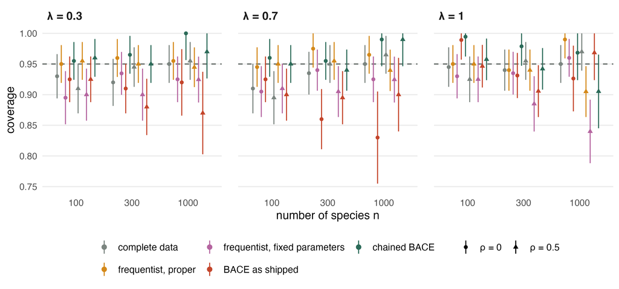

Figure 2: Coverage of ρ by the Rubin-pooled phylogenetic correlation, by n and λ (circles ρ = 0, triangles ρ = 0.5); whiskers ±2 Monte Carlo SE.

## 3.2 Discrete traits

### 3.2.1 Accuracy and calibration of imputed classes

At λ = 0.3 and 0.7 chained BACE imputed all three discrete traits more accurately than castor (Table 4, Figure 3): by 0.04 to 0.14 on the same datasets, in every scenario (5.6 to 28.4 SEs). At λ = 0.3 castor was less accurate than simply guessing the most frequent observed class for every species (by 0.008 to 0.020). castor’s flexible fits there have very large rates, so its draws follow the model’s stationary distribution and carry almost no phylogenetic information; with equal rates that distribution is uniform, which cost up to 0.08 accuracy. BACE’s lead was 0.04 to 0.10 at ρ = 0, where the other traits are uncorrelated with the imputed one but informative jointly with d1, and 0.06 to 0.14 at ρ = 0.5. At λ = 1 castor was as accurate or slightly more so (paired differences -0.016 to 0.001).

Table 4: Accuracy of the most frequent imputed class (Monte Carlo SE), pooled over ρ. Higher is better. The last column always guesses the most frequent observed class.

| trait | n | λ | frequentist, proper | frequentist, fixed parameters | frequentist proper, equal rates | BACE as shipped | chained BACE | most frequent class |
| --- | --- | --- | --- | --- | --- | --- | --- | --- |
| binary | 100 | 0.3 | 0.584 (0.006) | 0.585 (0.006) | 0.538 (0.005) | 0.668 (0.005) | 0.665 (0.005) | 0.597 (0.006) |
| binary | 100 | 0.7 | 0.727 (0.008) | 0.726 (0.008) | 0.695 (0.008) | 0.767 (0.006) | 0.779 (0.006) | 0.676 (0.008) |
| binary | 100 | 1.0 | 0.951 (0.003) | 0.950 (0.003) | 0.949 (0.003) | 0.932 (0.004) | 0.938 (0.003) | 0.719 (0.009) |
| binary | 300 | 0.3 | 0.603 (0.005) | 0.602 (0.005) | 0.530 (0.004) | 0.715 (0.003) | 0.718 (0.003) | 0.619 (0.005) |
| binary | 300 | 0.7 | 0.734 (0.007) | 0.732 (0.007) | 0.696 (0.008) | 0.808 (0.004) | 0.814 (0.004) | 0.695 (0.007) |
| binary | 300 | 1.0 | 0.971 (0.002) | 0.972 (0.002) | 0.972 (0.002) | 0.969 (0.002) | 0.969 (0.002) | 0.733 (0.007) |
| ordinal | 100 | 0.3 | 0.335 (0.006) | 0.333 (0.006) | 0.328 (0.006) | 0.411 (0.005) | 0.414 (0.006) | 0.343 (0.006) |
| ordinal | 100 | 0.7 | 0.488 (0.008) | 0.482 (0.009) | 0.462 (0.009) | 0.542 (0.007) | 0.543 (0.008) | 0.434 (0.008) |
| ordinal | 100 | 1.0 | 0.885 (0.004) | 0.891 (0.004) | 0.893 (0.004) | 0.871 (0.004) | 0.873 (0.004) | 0.538 (0.009) |
| ordinal | 300 | 0.3 | 0.324 (0.004) | 0.319 (0.005) | 0.316 (0.005) | 0.439 (0.004) | 0.439 (0.004) | 0.343 (0.005) |
| ordinal | 300 | 0.7 | 0.456 (0.007) | 0.455 (0.007) | 0.433 (0.008) | 0.573 (0.005) | 0.572 (0.005) | 0.422 (0.007) |
| ordinal | 300 | 1.0 | 0.930 (0.002) | 0.930 (0.002) | 0.930 (0.002) | 0.929 (0.002) | 0.927 (0.002) | 0.531 (0.008) |
| three-class | 100 | 0.3 | 0.421 (0.006) | 0.426 (0.006) | 0.362 (0.006) | 0.496 (0.006) | 0.496 (0.006) | 0.432 (0.007) |
| three-class | 100 | 0.7 | 0.566 (0.008) | 0.567 (0.008) | 0.500 (0.010) | 0.623 (0.007) | 0.628 (0.007) | 0.523 (0.008) |
| three-class | 100 | 1.0 | 0.913 (0.004) | 0.913 (0.004) | 0.916 (0.004) | 0.891 (0.004) | 0.895 (0.004) | 0.606 (0.009) |
| three-class | 300 | 0.3 | 0.434 (0.006) | 0.433 (0.006) | 0.362 (0.004) | 0.545 (0.004) | 0.543 (0.005) | 0.454 (0.006) |
| three-class | 300 | 0.7 | 0.583 (0.008) | 0.585 (0.008) | 0.515 (0.009) | 0.678 (0.005) | 0.677 (0.005) | 0.555 (0.008) |
| three-class | 300 | 1.0 | 0.953 (0.002) | 0.953 (0.002) | 0.954 (0.002) | 0.949 (0.002) | 0.949 (0.002) | 0.624 (0.009) |

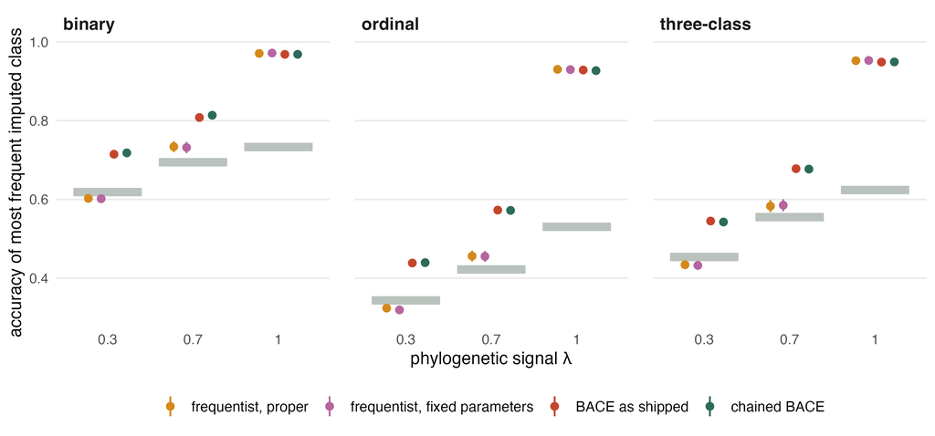

Figure 3: Accuracy of the most frequent imputed class at n = 300 by trait and λ, pooled over ρ; whiskers ±2 Monte Carlo SE. Grey bars: always guessing the most frequent observed class.

The 95% class sets and Brier scores (supplement) repeated the continuous pattern. At λ = 0.3 and n = 100 the sets of BACE as shipped covered 0.86 to 0.91 and chained BACE 0.89 to 0.94, below the 0.95 a calibrated 20-draw imputer reaches, and chaining lowered the Brier score in every λ ≤ 0.7 scenario (by 0.005 to 0.035).

### 3.2.2 A downstream association with a binary trait

Imputing each trait without the other biased their association (Table 5, Figure 4). At ρ = 0.5 and λ ≤ 0.7 the proper frequentist datasets pulled the slope of c1 on bin toward zero by 0.21 to 0.29. The bias did not shrink with n while the standard error did, so coverage fell from 0.89 at n = 100 to 0.34 to 0.46 at n = 300. At ρ = 0, where the true slope is zero, the same datasets biased the slope upward by 0.03 to 0.05. In plain terms: c1 and bin are each linked to the always-measured trait d1, so imputing c1 from d1 alone, and bin from the tree alone, creates a spurious positive link between them in the imputed species. (Formally, their correlation given d1 is −0.14, and imputing each without the other sets it to zero.) Their intervals nevertheless covered 0.990 to 1.000, because when the imputation model and the analysis model disagree about which variables are related, Rubin’s variance no longer measures the true sampling variance; here it overstated it (this mismatch is called uncongeniality; Meng 1994). BACE imputes bin given c1: at λ ≤ 0.7 its bias was -0.022 to 0.025 (chained -0.017 to 0.014) and it covered 0.895 to 0.945 as shipped and 0.940 to 0.965 chained, against 0.905 to 0.985 for the complete data. At λ = 1 and ρ = 0.5 the ranking reversed: the slope from BACE as shipped was 0.101 too small at n = 100 (SE 0.024), more than castor’s (0.055 proper, 0.019 fixed parameters; chained BACE 0.106), and all methods over-covered. A few BACE fits there had very large between-imputation variance (mean interval width up to about 100), so interval widths are not compared.

Table 5: PGLS slope of c1 on bin: coverage of the per-dataset target by the Rubin-pooled 95% interval, and bias of the pooled estimate (Monte Carlo SE). Compare coverage with the complete-data column.

| n | λ | ρ | coverage, complete data | coverage, frequentist, proper | coverage, frequentist, fixed parameters | coverage, BACE as shipped | coverage, chained BACE | bias, frequentist, proper | bias, frequentist, fixed parameters | bias, BACE as shipped | bias, chained BACE |
| --- | --- | --- | --- | --- | --- | --- | --- | --- | --- | --- | --- |
| 100 | 0.3 | 0.0 | 0.905 (0.021) | 1.000 (0.000) | 1.000 (0.000) | 0.900 (0.021) | 0.940 (0.017) | 0.047 (0.011) | 0.048 (0.011) | 0.010 (0.020) | 0.009 (0.018) |
| 100 | 0.3 | 0.5 | 0.980 (0.010) | 0.885 (0.023) | 0.870 (0.024) | 0.920 (0.019) | 0.950 (0.015) | -0.279 (0.009) | -0.281 (0.009) | -0.011 (0.017) | -0.017 (0.016) |
| 100 | 0.7 | 0.0 | 0.955 (0.015) | 1.000 (0.000) | 1.000 (0.000) | 0.940 (0.017) | 0.965 (0.013) | 0.037 (0.010) | 0.039 (0.011) | 0.025 (0.019) | 0.014 (0.016) |
| 100 | 0.7 | 0.5 | 0.985 (0.009) | 0.890 (0.022) | 0.890 (0.022) | 0.945 (0.016) | 0.960 (0.014) | -0.210 (0.009) | -0.208 (0.009) | -0.013 (0.016) | -0.017 (0.015) |
| 100 | 1.0 | 0.0 | 0.973 (0.012) | 1.000 (0.000) | 0.984 (0.009) | 0.994 (0.006) | 1.000 (0.000) | 0.040 (0.028) | 0.045 (0.032) | 0.000 (0.024) | -0.006 (0.017) |
| 100 | 1.0 | 0.5 | 0.973 (0.012) | 0.995 (0.005) | 0.989 (0.008) | 0.961 (0.016) | 0.987 (0.009) | -0.055 (0.027) | -0.019 (0.032) | -0.101 (0.024) | -0.106 (0.024) |
| 300 | 0.3 | 0.0 | 0.950 (0.015) | 0.995 (0.005) | 0.995 (0.005) | 0.900 (0.021) | 0.940 (0.017) | 0.049 (0.006) | 0.048 (0.005) | -0.022 (0.012) | 0.005 (0.011) |
| 300 | 0.3 | 0.5 | 0.955 (0.015) | 0.335 (0.033) | 0.290 (0.032) | 0.920 (0.019) | 0.945 (0.016) | -0.290 (0.006) | -0.292 (0.006) | 0.015 (0.010) | 0.006 (0.009) |
| 300 | 0.7 | 0.0 | 0.935 (0.017) | 0.990 (0.007) | 0.995 (0.005) | 0.895 (0.022) | 0.945 (0.016) | 0.028 (0.006) | 0.028 (0.006) | -0.011 (0.011) | -0.002 (0.010) |
| 300 | 0.7 | 0.5 | 0.965 (0.013) | 0.455 (0.035) | 0.460 (0.035) | 0.920 (0.019) | 0.955 (0.015) | -0.210 (0.007) | -0.209 (0.007) | 0.007 (0.009) | 0.003 (0.009) |
| 300 | 1.0 | 0.0 | 0.962 (0.014) | 1.000 (0.000) | 1.000 (0.000) | 0.989 (0.008) | 1.000 (0.000) | -0.004 (0.016) | -0.006 (0.021) | -0.017 (0.014) | -0.013 (0.014) |
| 300 | 1.0 | 0.5 | 0.962 (0.014) | 1.000 (0.000) | 1.000 (0.000) | 0.966 (0.014) | 0.966 (0.014) | -0.011 (0.019) | 0.012 (0.021) | -0.031 (0.013) | -0.041 (0.014) |

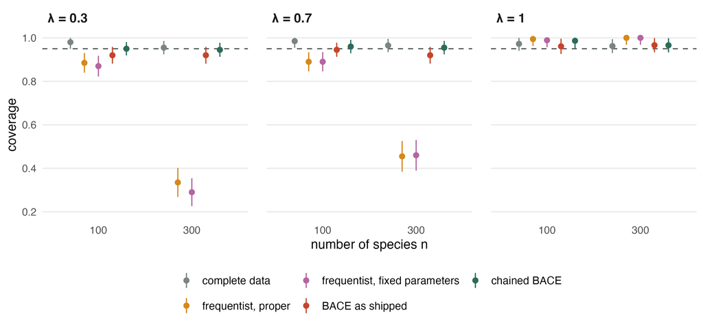

Figure 4: Coverage of the per-dataset target for the slope of c1 on bin at ρ = 0.5, by n and λ; whiskers ±2 Monte Carlo SE. Dashed line: 0.95.

## 3.3 Failures

BACE stopped with MCMCglmm’s “Mixed model equations singular” on 77 of 3,000 continuous-part datasets and 63 of 2,400 discrete-part datasets, all at λ = 1; chained BACE failed on 7 and 11 further datasets. At n ≤ 300, 62 of the 67 continuous-part failures recurred in the discrete run; 6 datasets failed in only one run, one of them on the same cluster both times. These counts are final failures. A first pass of BACE, before the input cleaning described in Section 2, left 169 failure records (1 at n = 300, λ = 0.7; 71 at n = 100, λ = 1; 97 at n = 300, λ = 1); those datasets were refitted after cleaning, and the final failures are the ones that still stopped. Failed fits are recorded and not scored, so BACE’s rows at λ = 1 rest on fewer datasets than the others (the tables give the counts); the datasets BACE failed on were, if anything, slightly easier for the frequentist method. The frequentist methods fitted every dataset apart from 3 Rphylopars failures in the continuous part. BACE returned no class for about 1.6% of its three-class draws (non-finite class probabilities); scores use the remaining draws. BACE’s own convergence check tests its deterministic settling phase and does not measure mixing, so it was not used to choose settings.

# 4 Discussion

BACE’s imputations as shipped are not proper. Every final imputation starts from the same dataset, whose missing entries were filled with posterior means rather than draws, so each imputation conditions on one fixed version of the other traits’ missing values. The draws for single values are too narrow, and the between-imputation variance misses the uncertainty in those fills; the downstream correlation, whose coverage fell to 0.83 at n = 1000, λ = 0.7 and ρ = 0, shows it directly. Chaining the final imputations is a small change that removes the shared start. Chained BACE then covered at or above nominal (conservatively at n = 1000) except for the correlation at λ = 1, ρ = 0.5 and n = 1000, and, at n ≥ 300 and λ ≤ 0.7, was more accurate per value than proper frequentist MI, though it attenuated the slope with correlated traits, most at small n and at λ = 1. Its successive imputations are consecutive sweeps of one chain, so independent chains, or several sweeps between retained imputations, may remove the remaining dependence.

The two parts of the study favour different methods for reasons that belong beside the results. The continuous traits follow the model Rphylopars fits, apart from prp’s extra noise, which biased the frequentist slope at λ = 1. The discrete traits are thresholded liabilities, the model family BACE fits, whereas castor treats each trait alone with an Mk process; cat3 was generated as an ordered trait and modelled as nominal by both methods. BACE’s advantage on discrete traits therefore mixes two sources, conditioning on the other traits and matching the data model, and this design cannot separate them.

The downstream result generalises beyond these tools. An imputation model that omits a variable of the analysis is uncongenial with it (Meng 1994): it pulls the association toward the value the imputer assumes (here zero), Rubin’s variance cannot correct that bias, and more data make the interval more confidently wrong. The recommendations in the box after the Introduction follow from these results.

## 4.1 Limitations

- One mechanism: Brownian motion with Pagel’s λ on random coalescent trees, MCAR 30%. Missing-at-random or clade-structured missingness, Ornstein-Uhlenbeck evolution and real trees were not studied, and no empirical example is included.
- The frequentist continuous model shares one λ across c1, c2, logit(prp) and d1. prp’s extra noise pulls that λ below 1 at λ = 1, which biased the frequentist slope and correlation by −0.018 to −0.026 at ρ = 0.5 at every n; at λ = 1 and ρ = 0.5 the proper method’s slope coverage was 0.955, 0.920 and 0.935 at n = 100, 300 and 1000, and its correlation coverage fell to 0.905 at n = 1000. The model also omits the count and discrete traits.
- Chained BACE and the extra-residual control were designed after a pre-run and tested on the same seeds.
- BACE at n = 1000 used 100 datasets per scenario (Monte Carlo SEs about 1.4 times the others’). The discrete part covers n = 100 and 300 only, so its trends in n rest on two sample sizes.
- The discrete traits follow BACE’s model family, and nominal traits generated from several liabilities were not simulated. An intercept-only BACE model and Mk-generated traits would separate model matching from conditioning.
- At λ = 1 about half of BACE’s fits needed input cleaning, and failed fits are not a random subset.
- At λ = 1 and ρ = 0.5 the target of the slope of c1 on bin varies between datasets by more than its standard error, so coverage there is read against the per-dataset target.

# 5 Data and code availability

All results, tables and code are on branch `arc/rubin-freq-bace` of the pigauto repository (the R package in which this study was run). This document is built from the tables in `data/`:

| file | contents |
| --- | --- |
| `data/fits.csv`, `data/discrete/fits.csv` | one row per fit: scenario, seed, cluster, node, time, wall times, errors, software versions |
| `data/fit_cells.csv.gz`, `data/fit_estimands.csv.gz` | continuous part: per fit × method × trait (per-value scores) and × estimand (pooled estimates) |
| `data/discrete/fit_disc_cells.csv.gz`, `fit_disc_estimands.csv.gz` | discrete part: per fit × method × trait and × estimand, with both targets |
| `data/agg/`, `data/discrete/agg_disc_*.csv` | aggregated tables used here |
| `data/discrete/truth_slope_c1_bin.csv` | Monte Carlo population target of the slope of c1 on bin |
| `data/discrete/repro.csv` | reproduction of the stored continuous fits by the discrete-part re-run |
| `data/bace_diagnostics.csv`, `data/discrete/bace_diagnostics.csv` | BACE convergence verdicts, effective sample sizes, input cleaning |
| `data/failure_records.csv`, `data/discrete/castor_diag.csv.gz` | first-pass BACE failures; castor fit diagnostics |

Code: `script/rubin_cell.R` generates and imputes one dataset with all methods; `script/campaign_gnn_off_lib.R` (`make_cell()`), `script/rubin_freq.R`, `script/rubin_bace.R`, `script/rubin_discrete.R` and `script/rubin_lib.R` hold data generation, methods and pooling; `script/rubin_campaign_aggregate.R`, `script/rubin_discrete_aggregate.R` and `script/rubin_study/build_data.R` build the tables; tests are in `script/tests-rubin/`. The raw per-fit result files, including every imputation of the discrete part (1.4 GB), are archived separately.

# Supplement

Table 6: Supplementary: Rubin-pooled downstream estimates by n, λ and ρ: coverage of ρ (Monte Carlo SE), bias and datasets scored.

| estimand | n | λ | ρ | method | coverage | bias | width | FMI | datasets |
| --- | --- | --- | --- | --- | --- | --- | --- | --- | --- |
| correlation | 100 | 0.3 | 0.0 | complete data | 0.930 (0.018) | 0.002 (0.008) | 0.388 | 0.000 | 200 |
| correlation | 100 | 0.3 | 0.0 | frequentist, proper | 0.950 (0.015) | 0.008 (0.010) | 0.533 | 0.477 | 200 |
| correlation | 100 | 0.3 | 0.0 | frequentist, fixed parameters | 0.895 (0.022) | 0.009 (0.010) | 0.464 | 0.309 | 200 |
| correlation | 100 | 0.3 | 0.0 | BACE as shipped | 0.925 (0.019) | 0.007 (0.011) | 0.505 | 0.407 | 200 |
| correlation | 100 | 0.3 | 0.0 | chained BACE | 0.955 (0.015) | 0.006 (0.010) | 0.537 | 0.465 | 200 |
| correlation | 100 | 0.3 | 0.0 | BACE + extra residual (control) | 0.965 (0.015) | 0.005 (0.009) | 0.521 | 0.446 | 200 |
| correlation | 100 | 0.3 | 0.5 | complete data | 0.910 (0.020) | 0.002 (0.006) | 0.294 | 0.000 | 200 |
| correlation | 100 | 0.3 | 0.5 | frequentist, proper | 0.955 (0.015) | 0.008 (0.007) | 0.401 | 0.472 | 200 |
| correlation | 100 | 0.3 | 0.5 | frequentist, fixed parameters | 0.900 (0.021) | 0.007 (0.008) | 0.350 | 0.302 | 200 |
| correlation | 100 | 0.3 | 0.5 | BACE as shipped | 0.925 (0.019) | -0.014 (0.008) | 0.390 | 0.403 | 200 |
| correlation | 100 | 0.3 | 0.5 | chained BACE | 0.960 (0.015) | -0.028 (0.007) | 0.428 | 0.470 | 200 |
| correlation | 100 | 0.3 | 0.5 | BACE + extra residual (control) | 0.930 (0.018) | -0.064 (0.008) | 0.423 | 0.428 | 200 |
| correlation | 100 | 0.7 | 0.0 | complete data | 0.910 (0.020) | 0.003 (0.008) | 0.388 | 0.000 | 200 |
| correlation | 100 | 0.7 | 0.0 | frequentist, proper | 0.945 (0.016) | 0.011 (0.010) | 0.532 | 0.468 | 200 |
| correlation | 100 | 0.7 | 0.0 | frequentist, fixed parameters | 0.905 (0.021) | 0.012 (0.010) | 0.466 | 0.311 | 200 |
| correlation | 100 | 0.7 | 0.0 | BACE as shipped | 0.925 (0.019) | -0.001 (0.010) | 0.514 | 0.410 | 200 |
| correlation | 100 | 0.7 | 0.0 | chained BACE | 0.960 (0.015) | 0.012 (0.010) | 0.546 | 0.494 | 200 |
| correlation | 100 | 0.7 | 0.0 | BACE + extra residual (control) | 0.950 (0.015) | -0.002 (0.009) | 0.526 | 0.435 | 200 |
| correlation | 100 | 0.7 | 0.5 | complete data | 0.895 (0.022) | 0.004 (0.006) | 0.293 | 0.000 | 200 |
| correlation | 100 | 0.7 | 0.5 | frequentist, proper | 0.950 (0.015) | 0.008 (0.007) | 0.403 | 0.466 | 200 |
| correlation | 100 | 0.7 | 0.5 | frequentist, fixed parameters | 0.910 (0.020) | 0.006 (0.008) | 0.352 | 0.301 | 200 |
| correlation | 100 | 0.7 | 0.5 | BACE as shipped | 0.900 (0.021) | -0.015 (0.009) | 0.414 | 0.423 | 200 |
| correlation | 100 | 0.7 | 0.5 | chained BACE | 0.950 (0.015) | -0.034 (0.008) | 0.452 | 0.509 | 200 |
| correlation | 100 | 0.7 | 0.5 | BACE + extra residual (control) | 0.895 (0.022) | -0.061 (0.009) | 0.440 | 0.445 | 200 |
| correlation | 100 | 1.0 | 0.0 | complete data | 0.945 (0.016) | 0.001 (0.008) | 0.388 | 0.000 | 200 |
| correlation | 100 | 1.0 | 0.0 | frequentist, proper | 0.950 (0.015) | -0.006 (0.010) | 0.528 | 0.463 | 200 |
| correlation | 100 | 1.0 | 0.0 | frequentist, fixed parameters | 0.930 (0.018) | -0.004 (0.010) | 0.474 | 0.330 | 200 |
| correlation | 100 | 1.0 | 0.0 | BACE as shipped | 0.989 (0.016) | -0.015 (0.010) | 0.583 | 0.490 | 185 |
| correlation | 100 | 1.0 | 0.0 | chained BACE | 0.995 (0.016) | -0.001 (0.009) | 0.658 | 0.573 | 182 |
| correlation | 100 | 1.0 | 0.0 | BACE + extra residual (control) | 0.984 (0.016) | -0.013 (0.009) | 0.579 | 0.472 | 185 |

[output cut: 186 more lines]

Table 7: Supplementary: z-RMSE of single missing values of c1 and c2 (SD units; Monte Carlo SE), pooled over ρ.

| n | λ | frequentist, proper | frequentist, fixed parameters | BACE as shipped | chained BACE | BACE + extra residual (control) |
| --- | --- | --- | --- | --- | --- | --- |
| 100 | 0.3 | 0.871 (0.006) | 0.871 (0.006) | 0.989 (0.008) | 0.896 (0.006) | 0.997 (0.008) |
| 100 | 0.7 | 0.709 (0.006) | 0.709 (0.006) | 0.799 (0.008) | 0.736 (0.007) | 0.806 (0.008) |
| 100 | 1.0 | 0.229 (0.005) | 0.230 (0.005) | 0.275 (0.006) | 0.252 (0.005) | 0.275 (0.006) |
| 300 | 0.3 | 0.854 (0.004) | 0.853 (0.004) | 0.911 (0.006) | 0.837 (0.004) | 0.923 (0.006) |
| 300 | 0.7 | 0.694 (0.005) | 0.694 (0.005) | 0.724 (0.006) | 0.685 (0.005) | 0.733 (0.006) |
| 300 | 1.0 | 0.146 (0.003) | 0.146 (0.003) | 0.155 (0.003) | 0.150 (0.003) | 0.155 (0.003) |
| 1000 | 0.3 | 0.833 (0.003) | 0.832 (0.003) | 0.862 (0.008) | 0.804 (0.005) | 0.875 (0.008) |
| 1000 | 0.7 | 0.663 (0.005) | 0.663 (0.005) | 0.676 (0.008) | 0.646 (0.007) | 0.687 (0.008) |
| 1000 | 1.0 | 0.079 (0.001) | 0.079 (0.001) | 0.082 (0.002) | 0.081 (0.002) | 0.082 (0.002) |

Table 8: Supplementary: Brier score and coverage of the 95% class set of the 20 draws (Monte Carlo SE), pooled over ρ.

| trait | n | λ | Brier, frequentist, proper | Brier, BACE as shipped | Brier, chained BACE | set coverage, frequentist, proper | set coverage, BACE as shipped | set coverage, chained BACE |
| --- | --- | --- | --- | --- | --- | --- | --- | --- |
| binary | 100 | 0.3 | 0.500 (0.005) | 0.492 (0.007) | 0.465 (0.007) | 0.988 (0.001) | 0.909 (0.003) | 0.940 (0.002) |
| binary | 100 | 0.7 | 0.373 (0.008) | 0.345 (0.008) | 0.317 (0.007) | 0.966 (0.002) | 0.940 (0.003) | 0.961 (0.002) |
| binary | 100 | 1.0 | 0.085 (0.005) | 0.104 (0.005) | 0.099 (0.005) | 0.983 (0.002) | 0.984 (0.002) | 0.988 (0.001) |
| binary | 300 | 0.3 | 0.482 (0.003) | 0.401 (0.004) | 0.379 (0.004) | 0.995 (0.001) | 0.957 (0.001) | 0.976 (0.001) |
| binary | 300 | 0.7 | 0.364 (0.007) | 0.281 (0.005) | 0.266 (0.005) | 0.970 (0.002) | 0.958 (0.001) | 0.970 (0.001) |
| binary | 300 | 1.0 | 0.049 (0.003) | 0.050 (0.002) | 0.049 (0.002) | 0.987 (0.001) | 0.992 (0.001) | 0.993 (0.001) |
| ordinal | 100 | 0.3 | 0.769 (0.004) | 0.747 (0.006) | 0.724 (0.006) | 0.918 (0.003) | 0.859 (0.004) | 0.888 (0.003) |
| ordinal | 100 | 0.7 | 0.647 (0.008) | 0.607 (0.009) | 0.584 (0.008) | 0.908 (0.003) | 0.886 (0.003) | 0.908 (0.003) |
| ordinal | 100 | 1.0 | 0.181 (0.006) | 0.193 (0.005) | 0.192 (0.005) | 0.973 (0.002) | 0.975 (0.002) | 0.978 (0.002) |
| ordinal | 300 | 0.3 | 0.762 (0.003) | 0.682 (0.004) | 0.668 (0.003) | 0.943 (0.002) | 0.915 (0.002) | 0.936 (0.001) |
| ordinal | 300 | 0.7 | 0.661 (0.006) | 0.549 (0.006) | 0.539 (0.006) | 0.919 (0.002) | 0.933 (0.002) | 0.946 (0.001) |
| ordinal | 300 | 1.0 | 0.117 (0.003) | 0.111 (0.003) | 0.112 (0.003) | 0.975 (0.001) | 0.985 (0.001) | 0.987 (0.001) |
| three-class | 100 | 0.3 | 0.685 (0.005) | 0.703 (0.007) | 0.680 (0.007) | 0.956 (0.002) | 0.892 (0.003) | 0.906 (0.003) |
| three-class | 100 | 0.7 | 0.559 (0.008) | 0.540 (0.010) | 0.522 (0.009) | 0.938 (0.003) | 0.920 (0.003) | 0.929 (0.003) |
| three-class | 100 | 1.0 | 0.142 (0.005) | 0.167 (0.006) | 0.162 (0.006) | 0.976 (0.002) | 0.977 (0.002) | 0.980 (0.002) |
| three-class | 300 | 0.3 | 0.659 (0.004) | 0.583 (0.004) | 0.571 (0.004) | 0.971 (0.001) | 0.941 (0.001) | 0.954 (0.001) |
| three-class | 300 | 0.7 | 0.537 (0.008) | 0.442 (0.006) | 0.435 (0.006) | 0.942 (0.002) | 0.945 (0.001) | 0.952 (0.001) |
| three-class | 300 | 1.0 | 0.081 (0.003) | 0.079 (0.003) | 0.079 (0.003) | 0.981 (0.001) | 0.987 (0.001) | 0.988 (0.001) |

Table 9: Supplementary: wall time per fit (one dataset, all methods of the set) on one core.

| part | set | n | median hours | 90th percentile hours |
| --- | --- | --- | --- | --- |
| continuous | bace | 100 | 0.64 | 0.70 |
| continuous | freq | 100 | 0.01 | 0.01 |
| continuous | bace | 300 | 1.65 | 2.00 |
| continuous | freq | 300 | 0.02 | 0.02 |
| continuous | bace | 1000 | 5.47 | 7.09 |
| continuous | freq | 1000 | 0.07 | 0.09 |
| discrete | bace | 100 | 0.62 | 0.67 |
| discrete | freq | 100 | 0.01 | 0.01 |
| discrete | bace | 300 | 1.74 | 1.92 |
| discrete | freq | 300 | 0.02 | 0.03 |

Table 10: Supplementary: continuous part by n and λ. files: result files; bace_errors: BACE fits that stopped; freq_errors: Rphylopars fits that failed; bace_cleaned: BACE fits whose inputs needed empty levels dropped or a trait left out; freqA refit columns: bootstrap refits redrawn. Rows labelled bace_asshipped_failed are first-pass BACE runs, before input cleaning, kept as records.

| set | n | lambda | files | bace_errors | freq_errors | bace_cleaned | freqA_refit_fail | freqA_degenerate |
| --- | --- | --- | --- | --- | --- | --- | --- | --- |
| bace | 100 | 0.3 | 400 | 0 | 0 | 0 | 0 | 0 |
| freq | 100 | 0.3 | 400 | 0 | 0 | 0 | 1 | 1 |
| bace | 300 | 0.3 | 400 | 0 | 0 | 0 | 0 | 0 |
| freq | 300 | 0.3 | 400 | 0 | 1 | 0 | 12 | 1 |
| bace | 1000 | 0.3 | 200 | 0 | 0 | 0 | 0 | 0 |
| freq | 1000 | 0.3 | 400 | 0 | 1 | 0 | 0 | 0 |
| bace | 100 | 0.7 | 400 | 0 | 0 | 25 | 0 | 0 |
| freq | 100 | 0.7 | 400 | 0 | 0 | 0 | 0 | 1 |
| bace | 300 | 0.7 | 400 | 0 | 0 | 10 | 0 | 0 |
| bace_asshipped_failed | 300 | 0.7 | 1 | 1 | 0 | 0 | 0 | 0 |
| freq | 300 | 0.7 | 400 | 0 | 0 | 0 | 1 | 1 |
| bace | 1000 | 0.7 | 200 | 0 | 0 | 2 | 0 | 0 |
| freq | 1000 | 0.7 | 400 | 0 | 1 | 0 | 0 | 5 |
| bace | 100 | 1.0 | 400 | 47 | 0 | 187 | 0 | 0 |
| bace_asshipped_failed | 100 | 1.0 | 71 | 71 | 0 | 0 | 0 | 0 |
| freq | 100 | 1.0 | 400 | 0 | 0 | 0 | 0 | 2 |
| bace | 300 | 1.0 | 400 | 20 | 0 | 195 | 0 | 0 |
| bace_asshipped_failed | 300 | 1.0 | 97 | 97 | 0 | 0 | 0 | 0 |
| freq | 300 | 1.0 | 400 | 0 | 0 | 0 | 0 | 1 |
| bace | 1000 | 1.0 | 200 | 10 | 0 | 90 | 0 | 0 |
| freq | 1000 | 1.0 | 400 | 0 | 0 | 0 | 45 | 0 |

# References

- Barnard, J. & Rubin, D. B. (1999). Small-sample degrees of freedom with multiple imputation. *Biometrika* 86, 948–955.
- Brier, G. W. (1950). Verification of forecasts expressed in terms of probability. *Monthly Weather Review* 78, 1–3.
- Gneiting, T. & Raftery, A. E. (2007). Strictly proper scoring rules, prediction, and estimation. *Journal of the American Statistical Association* 102, 359–378.
- Goolsby, E. W., Bruggeman, J. & Ané, C. (2017). Rphylopars: fast multivariate phylogenetic comparative methods for missing data and within-species variation. *Methods in Ecology and Evolution* 8, 22–27.
- Hadfield, J. D. (2010). MCMC methods for multi-response generalized linear mixed models: the MCMCglmm R package. *Journal of Statistical Software* 33(2), 1–22.
- Louca, S. & Doebeli, M. (2018). Efficient comparative phylogenetics on large trees. *Bioinformatics* 34, 1053–1055.
- Meng, X.-L. (1994). Multiple-imputation inferences with uncongenial sources of input. *Statistical Science* 9, 538–558.
- Morris, T. P., White, I. R. & Crowther, M. J. (2019). Using simulation studies to evaluate statistical methods. *Statistics in Medicine* 38, 2074–2102.
- Nakagawa, S. & Freckleton, R. P. (2008). Missing inaction: the dangers of ignoring missing data. *Trends in Ecology & Evolution* 23, 592–596.
- Pagel, M. (1999). Inferring the historical patterns of biological evolution. *Nature* 401, 877–884.
- Paradis, E. & Schliep, K. (2019). ape 5.0: an environment for modern phylogenetics and evolutionary analyses in R. *Bioinformatics* 35, 526–528.
- Rubin, D. B. (1987). *Multiple Imputation for Nonresponse in Surveys*. Wiley, New York.
- Williams et al. (2024). Transparent reporting items for simulation studies evaluating statistical methods. *Methods in Ecology and Evolution* 15, 1926–1939. (Author list to be checked before submission.)